# Short-term impact of a malaria elimination campaign in Southern Mozambique

## Introduction

## The burden of malaria

- 2015: 212M cases; 429K deaths (global).
- Mozambique among ten highest burden countries in world.
- 29% reduction since 2010.
- Now, focus on *elimination* and *eradication*.

## How to eliminate

- Mass drug administration (MDA).
- Other, more time-tested strategies (ITNs, IRS).
- The need for operational research.

## It's hard to evaluate elimination strategies

- Difficult to measure impact of interventions in operational research.
- OR is usually not experimental, not randomized, not controlled.
- Before vs. after and case vs. control approaches are useful, but biased.

## Why evaluate?

- The WHO explicitly supports “the need for more research on the optimum methods of implementing MDA programs, promoting community participation and compliance with treatment, and evaluating their effectiveness.
- As elimination initiatives imply both strong financial/economic efforts and a high risk of failure, their affordability, sustainability and cost-effectiveness are among the main concerns of funders, stakeholders and policymakers
- Evidence of the causal impact of malaria elimination initiatives is a pre-requisite for evaluating their cost-effectiveness. Finally, rigorous impact evaluations of malaria elimination programs are essential for sustained financial and political support.

## How to evaluate?

- Since we don't have an experiment, we need quasi-experimental approaches.
- The synthetic control method (SCM).
- We want to construct a *realistic* counterfactual telling us *what would have happened* without the campaign.

## What are we evaluating, exactly?

- Malaria elimination campaign in Magude.
- Deployed during rainy seasons of 2015-6 and 2016-7.
- Consisted of MDA, IRS, and surveillance.
- ITN coverage was already high from 2014.

## Methods

## Data

- Mozambique’s Boletim Epidemiológico Semanal (BES) of the NMCP.
- Weekly clinical cases, by age group, by health facility, for each of a few high risk diseases , the epidemic disease reporting system used by the NMCP.
- Population estimates from the National Statistical Institute (INE).

## Identification strategy

- Treatment group is district of Magude, Maputo province.
- Control group consists of the other districts in Maputo and Gaza province.
- The selection of control districts from locations around Magude is to ensure treatment and control groups have similar epidemiological characteristics.

## Co-variates

Our analysis uses variables as predictors of malaria incidence:

- LLINs
- Average weekly temperature
- Weekly rainfall

## Rainfall

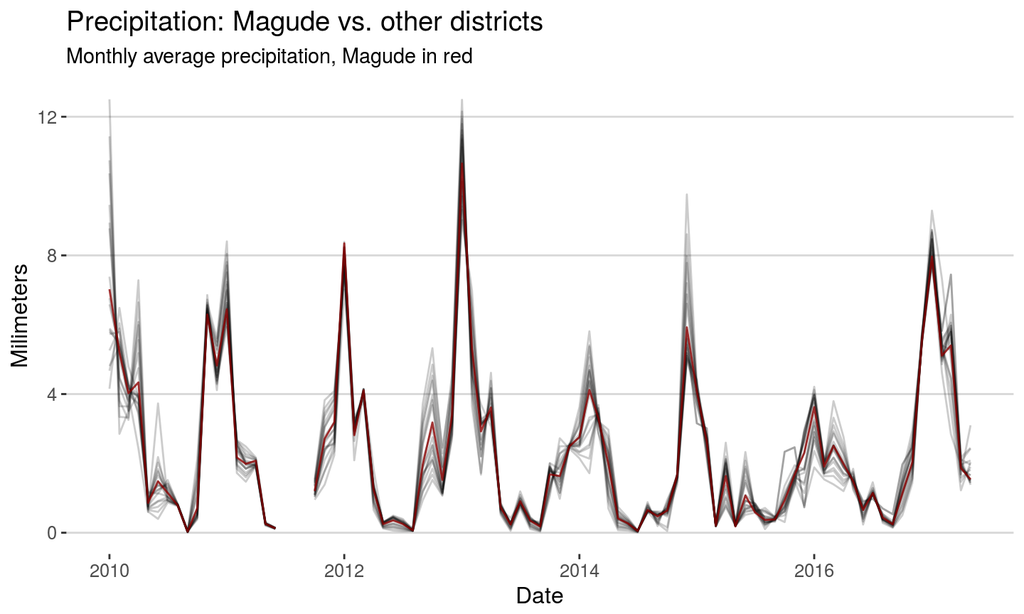

## Temperature

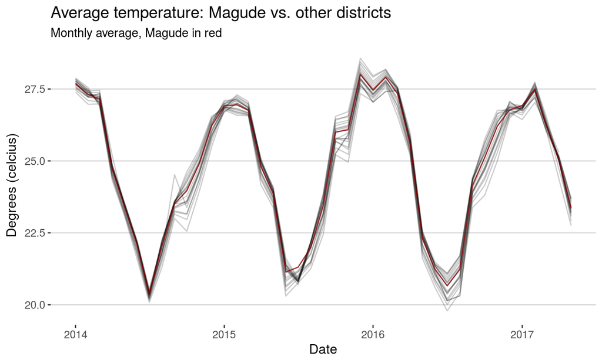

## Difference in differences

- We *could* compare changes in malaria incidence to other districts using a difference-in-differences (DD) model.
- Often used to estimate treatment effects in such settings by contrasting changes in outcome pre- and -post intervention, for the treatment and control groups.
- Eliminates confounding due to time-invariant differences between treatment and control groups, arising from unobservable factors that might influence malaria incidence.
- Assumes that any macro shocks such as time effects are common to the groups under evaluation.

## Why we can't use difference in differences

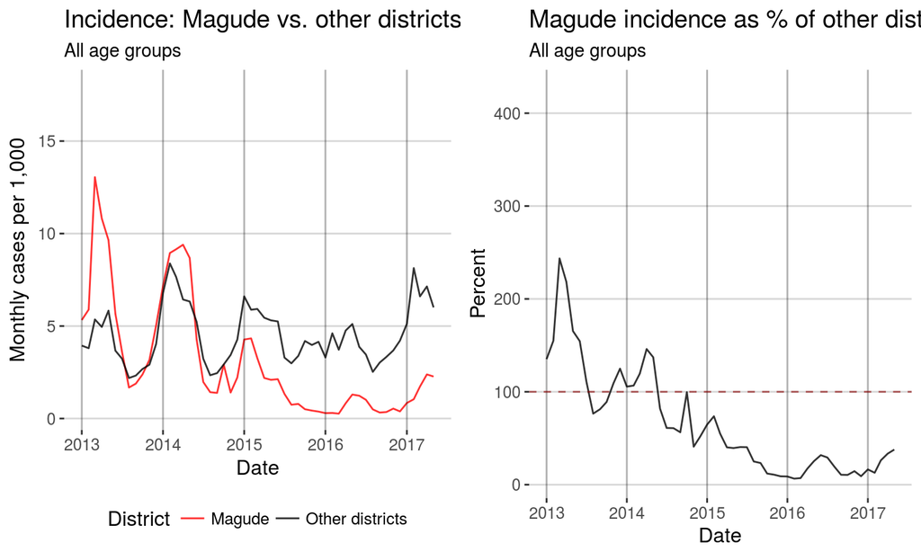

## Why not DiD?

- Magude shows a downward trend in incidence over time, even prior to the elimination campaign.
- Lack of a visible parallel trend between treatment and control groups

## SCM

- We employ the synthetic control method (SCM).
- Weighted combination of potential control districts, the synthetic control, using the districts that best approximate the most relevant characteristics of malaria incidence in Magude before the intervention.
- Characteristics include pre-intervention malaria incidence during rainy season, temperature and and rainfall.
- Good match based on RMSE.

## Advantages of SCM

- Makes explicit the relative contribution of selected control districts to the counterfactual; the similarities between Magude and the synthetic control can be evaluated by comparing pre-intervention outcomes and predictors.
- Allows the effects of unobserved factors on malaria incidence to vary with time, relaxing the parallel trend assumption of DD discussed earlier.

## Limitations of SCM

- Does not allow assessing the significance of the results using commonly used (large-sample) inferential techniques.
- Instead, we use placebo experiments based on permutation techniques to make inference: sequentially applying the SCM assuming each control district was “treated” to generate a distribution of placebo effects, and compare Magude's effect with these distributions.

## Results

## Overview

- Relative to the synthetic control, the average treatment effect during the first postintervention malaria season was a reduction in weekly incidence by 4 and 2 cases per 1,000 in those aged 0-4 and 5 or older, respectively.
- During peak malaria season (January - March), 1,939 cases were prevented in 2016, and 3,405 in 2017.
- This represents a 91.29% and 81.3% reduction in the incidence of malaria relative to the hypothetical control.

## All districts' incidences (aggregated age groups)

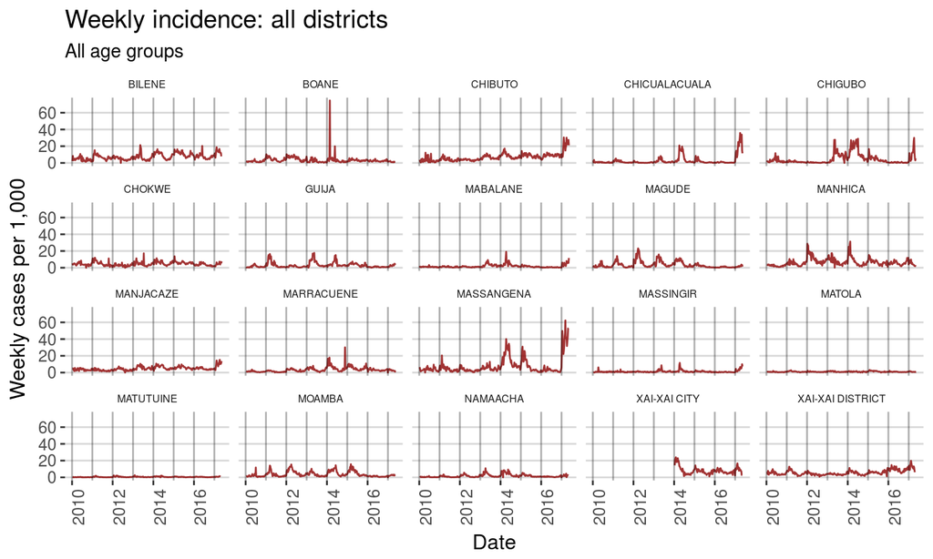

## All districts' incidences (separated by age groups)

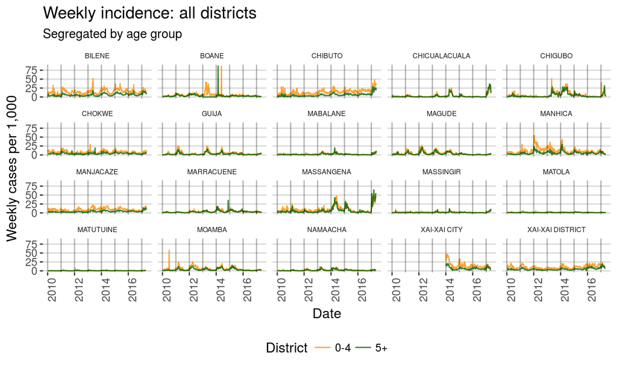

## Magude vs. other districts

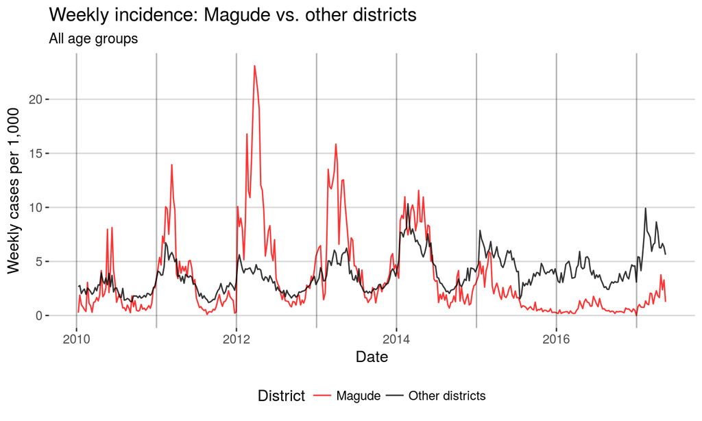

## Magude vs. other districts (separated by age group)

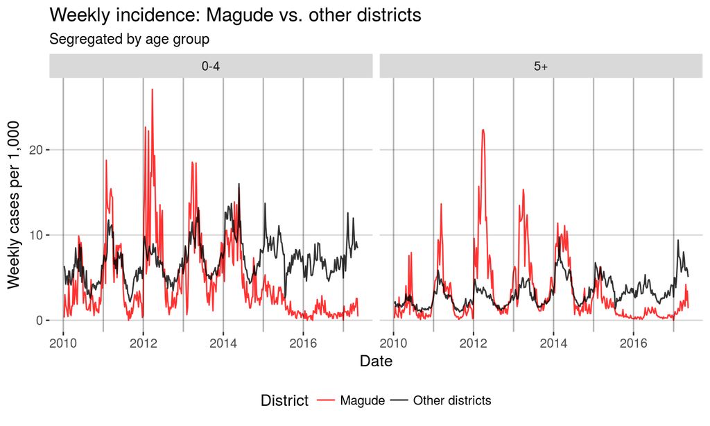

## Our weighted synthetic control

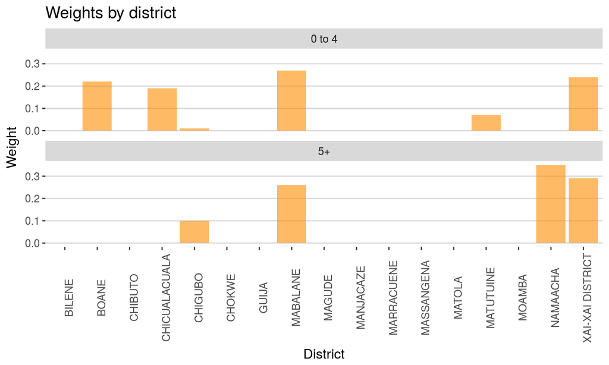

## Is it a good match?

| Indicator | Magude 0-4 | Synthetic Magude 0-4 | Magude 5+ | Synthetic Magude 5+ |
| --- | --- | --- | --- | --- |
| Incidence, rainy season 2015 | 3.65 | 5.10 | 4.02 | 4.12 |
| Incidence, rainy season 2014 | 8.87 | 6.93 | 8.53 | 6.29 |
| LLIN coverage | 24.82 | 24.77 | 24.83 | 25.22 |
| Pre-intervention precipitation | 1.71 | 1.74 | 1.70 | 1.71 |
| Pre-intervention temperature | 24.52 | 24.51 | 24.52 | 24.49 |
| Post-intervention precipitation | 1.84 | 1.82 | 1.84 | 1.83 |

## 0-4 year-olds: Magude vs synthetic control

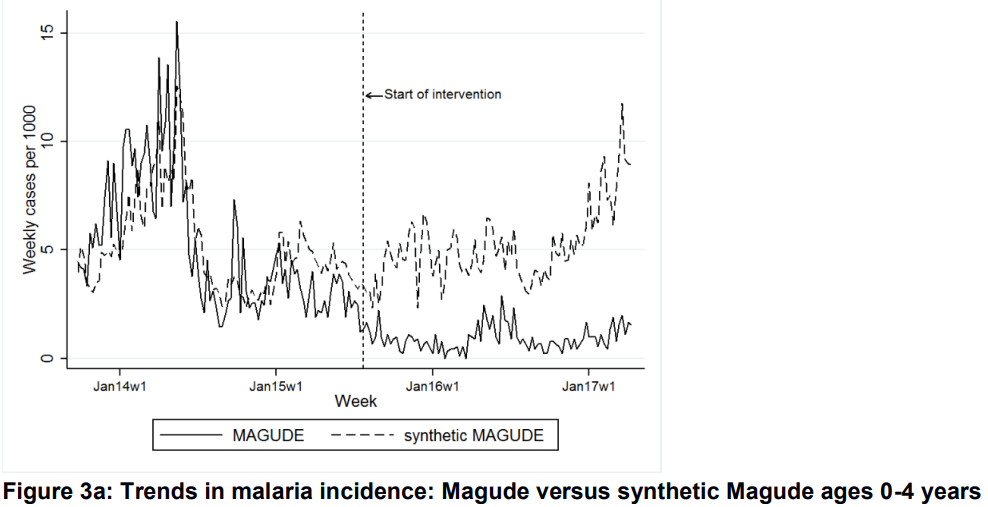

## 5+ year-olds: Magude vs synthetic control

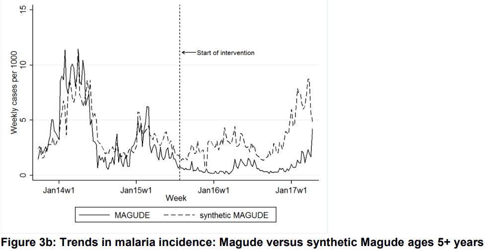

## Effect of interevention

Relative to the synthetic control, the average treatment effect during the first post-intervention malaria season was a reduction in weekly incidence by 4 and 2 cases per 1,000 in those aged 0-4 and 5 or older, respectively. During peak malaria season (January - March), 1,939 cases were prevented in 2016, and 3,405 in 2017.

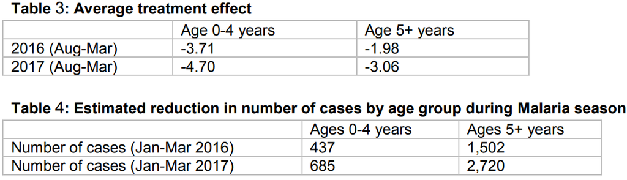

This represents a 91.29% and 81.3% reduction in the incidence of malaria relative to the hypothetical control.

## Discussion

## Our findings

- Across age groups during the peak malaria season (January-March) incidence declined by 91.29% and 81.3% in 2016 and 2017, respectively.
- Has not achieved zero cases.
- Unsure, at this point, to what extent we can attribute cases to importation and abnormal weather.

## Comparison with other findings

- Similar findings obtained in a cluster randomized controlled trial (RCT) estimating the effectiveness of MDA with DHA/PPQ in Zambia.
- In that study, while the number of malaria cases significantly declined after MDA in low-transmission areas, drop was not significant in areas of high transmission (ie, Magude).
- Also consistent with the predictions of a consensus study that put together 4 models focusing on the impact of MDA with a drug having similar characteristics as DHA/PPQ.
- The latter predicted an immediate (but transient w/o other interventions) decline in malaria prevalence after MDA.

## Quasi-experimental methods in similar contexts

- Quasi-experimental approaches have been applied in other elimination campaigns.
- Barofsky et al. used SCM as an approach for the identification of the impact of a malaria campaign in a district in Uganda.
- These studies are from 50s-60s and look at economic indicators, such as primary school completion or households consumption.
- To our knowledge, this is the first quasi-experimental evaluation of an ongoing elimination initiative using routine national surveillance data on health indicators.

## Comparison with RCT

- Randomized control trials (RCTs) are the gold standard for impact evaluations.
- However, the implementation of RCTs may imply financial, practical and ethical challenges.
- Furthermore, RCTs have debatable usefulness in identifying intervention feasibility and implementation bottlenecks, which are particularly important in disease elimination contexts.
- Quasi-experimental approaches are particularly useful when applied to routinely collected (administrative/observational) data.

## Scaling up the method?

- Given the focus over the last decade on malaria elimination with both large and small scale campaigns across the globe – quasi-experimental approaches offer a rigorous and inexpensive alternative to randomized-control trials.
- Observational data is widely (and often publicly) available and true experimental approaches are often not feasible: quasi-experimental approaches like the SCM are an excellent alternative for the evaluation of malaria elimination initiatives.
- Approach is not only suitable for the estimation of the impact of the intervention in question, but also generalizable to malaria elimination campaigns globally.

## Limitations

1. We rely on surveillance malaria cases reported at the health facility level, which is an incomplete and imperfect proxy for true malaria infection incidence since health-seeking behavior is especially low in low-income countries settings and may be different across geography and time.
2. The health facility registries from which we gathered data are themselves imperfect; we have no mechanisms by which to validate the entirety of the data. Still, BES data offers the best country-wide comparison of malaria trends at a granular level (weekly and by district).
3. Even with quasi-experimental data, we still can't fully control for abnormalities… (see next slide)

## 2017 has been anything but normal

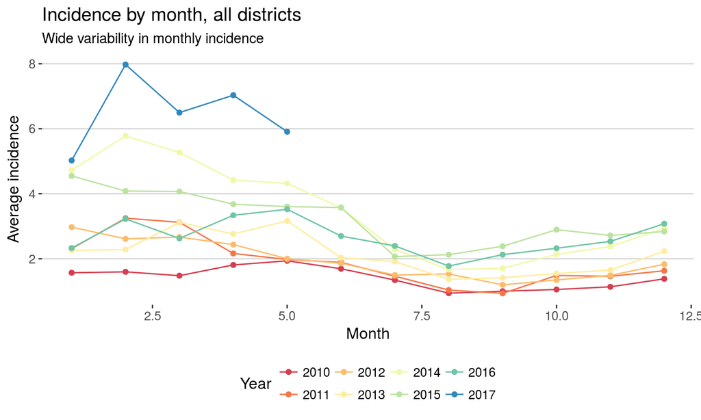

## Implications

- The strategy reduced malaria significantly.
- Effectiveness quantified accurately enough to allow for granular cost-effectiveness.
- Synthetic control method useful and generalizable for the estimation of similar initiatives’ effectiveness.
- Policy-makers, researchers, and those actively engaged in or planning disease elimination initiatives, can benefit from both the methods and findings from this study.

## Acknowledgments

- NMCP for releasing BES data.
- CISM for support.
- Bill and Melinda Gates Foundation and “La Caixa” Foundation for funding MALTEM.
- JB is funded by the Trans Global Health doctorate program.